# OMSBA 5300 Summer 2022 Data Translation Challenge

Jomaica Alfiler, Jill Thompson, Taylor Mack, Erik Campbell, Kristen Higashi

8/27/2022

### Background & Assumptions

Our study was shaped using unemployment figures by industry, geography, race and age from January 2019 through December 2021. Operating under the guidance that anything before March 2020 was “Pre-Covid” and anything after March 2020 was “Post-Covid” we broke our data into three distinct time periods. These time periods were Pre-Covid (JAN 2019 -through Feb 2020), Covid (March 2020) and Post-Covid (April 2020-through- December 2021) and evaluated changes in unemployment over time by industry, changes to unemployment by geography, race and age. We made assumptions when evaluating industry unemployment that jobs numbers in relation to different industries are similar; however, employment in one industry(e.g. technology, healthcare) versus employment in the leisure and hospitality industry lead to differing amounts of discretionary income available to consumers.

We did not take into account household savings and debt rates from Jan 2019 through Dec 2021, and these factors play a role in discretionary income families have to spend. In the future, we’d take into account and create family income on the monthly level and not just industry members of household worked in, but account for their job. Future research is recommended to account for jobs within industries that can be performed from an employee’s home in order to assist in identifying and quantifying how many earners moved from cities to suburbs or rural areas. Cohorts that relocated during the pandemic to suburbs, working in high-earning occupations, present an opportunity for businesses to meet customers demands at different geographic locations.

### Change the below location to where your data files exist

**Raw Data**:

```r
#Question 1 Dataloads

q1_employment <- read_dta('Q1.dta.zip')
covid_history <- read_csv('covid_history.csv')
state_lockdowns <- read_csv('state_lockdowns.csv')
state_names <- read_csv('state_names.csv')
timeline <- read_csv('timeline.csv')

#Question 2 Dataloads
industry_names <- read.csv('indnames.csv') %>%
  mutate(industry_cat = case_when(
    indname == 'Retail Trade' ~ 'Retail',
    indname != 'Retail Trade' ~ 'Non-Retail'))
q2_data <- read_dta('./Q2.dta.gz')

#Question 3 Dataloads

###### Read in State Federal Information Processing Codes. ######
state_fips <- read_csv('state-geocodes-v2021.csv') %>%
  filter(!is.na(Region)) %>%
  rename(State = Name)
  #select(STATEFIP, State)
###### read in IPUMS demographic data from
dem_ddi <- read_ipums_ddi("cps_00016.xml")
dem_data <- read_ipums_micro(dem_ddi) %>%
  zap_labels() %>%
  mutate(
    month_digit= case_when(
      nchar(str_trim(as.character(MONTH))) ==1 ~ (paste('0',str_trim(as.character(MONTH)), sep = '')),
      nchar(str_trim(as.character(MONTH))) ==2 ~ (str_trim(as.character(MONTH))),
      TRUE ~ 'WRONG'
    )
    , date_ = as_date(paste(YEAR, month_digit, '01', sep = '-'))
    , period_type = as_factor(case_when(
      date_ < '2020-03-01' ~'Pre_Covid',
      date_ >= '2020-03-01' & date_ < '2020-04-01' ~'Covid',
      date_ >= '2020-04-01' ~'Post_Covid'
    ))
  )
```

```
## Use of data from IPUMS CPS is subject to conditions including that users should
## cite the data appropriately. Use command `ipums_conditions()` for more details.
```

### Setting up Functions to be help with Data Wrangling

```r
#Q1 Data Wrangling
t_emp <- q1_employment %>% filter(!(whyunemp == 0)) %>%
  filter(occ2010 %in% c(4700:5790)) %>%
  filter(whyunemp %in% c(1,2,3)) %>%
  class_conversion(c('month', 'durunemp', 'statefip'), as.numeric) %>%
  class_conversion(c('occ', 'covidunaw', 'whyunemp'), as.factor) %>%
  select(-'serial')

t_state_lockdowns <- state_lockdowns %>%
  mutate(lockdown_start = mdy(lockdown_start))

### covid history data
state_name_key <- read.csv('state_names.csv')

state_name_key <- state_name_key %>% select(-'Abbrev')

names(state_name_key)[2] <- 'Code'

names(covid_history)[2] <- 'Code'

t_covid_history <- covid_history %>%
  left_join(state_name_key, 'Code')%>%
  mutate(date = mdy(date))

### employment data
exp_emp <- t_emp %>%
  na.omit()%>%
  mutate(survey_dates = ymd(paste0(year, '-', month, '-01')))%>%
  group_by(year, month, statefip) %>%
  mutate(layoff = ifelse(whyunemp == 1,1,0), # if reason is layoff = 1, if not = 0
         other_type_loss = ifelse(whyunemp == 2,1,0),
         temp_emp = ifelse(whyunemp == 3,1,0),
         covidunaw=ifelse(covidunaw==1,1,0))%>%
  mutate(covid_impact_no = ifelse(covidunaw == 0,1,0),
         covid_impact_yes = ifelse(covidunaw == 1,1,0))%>%
  left_join(t_state_lockdowns, 'statefip')

#Q2 Data Wrangling
###Joining the initial data read with the industry_name dataframe
q2_df <- left_join(q2_data,industry_names,by= "ind") %>%
  mutate(cpsid = format(cpsid,scientific= FALSE)) %>%
  mutate(cpsidp = format(cpsidp,scientific= FALSE)) %>%
  mutate(date = as_date(paste(year, month, '01', sep = '-'))) %>%
  mutate(covid_active = case_when(date >= '2020-03-01' ~ 1,
                                  date < '2020-03-01' ~ 0))
###Filtering for employed and cpsidp's that are not zero
filtered_df <- q2_df %>% filter(cpsidp > 0) %>%
  filter(empstat <20 & empstat >= 10) %>% #20 and above indicates they are unemployed/no looking
  group_by(date,indname) %>%
  mutate(emp_count = n())

###Creating a dataframe that will be used to graph the dataset to compare retail vs non-retail
industry_df <- filtered_df %>%
  ungroup() %>%
  select(c('indname','year','date','covid_active','emp_count')) %>%
  distinct() %>%
  group_by(indname,date) %>%
  mutate(count = sum(emp_count))%>%
  select(-c(5))%>%
  distinct() %>%
  ungroup()%>%
  group_by(indname)%>%
  mutate(percent_change = ((count-lag(count))/lag(count)))%>%
  mutate(percent_change = case_when(
    percent_change = is.na(percent_change) ~ 0,
    percent_change == is.na(percent_change) ~ 0,
    percent_change != is.na(percent_change) ~ percent_change))

###Creating a dataframe that will be used to graph the dataset to compare retail vs non-retail
industry_cat_df <- filtered_df %>%
               ungroup() %>%
               select(c('industry_cat','year','date','covid_active','emp_count')) %>%
               distinct() %>%
               group_by(industry_cat,date) %>%
               mutate(count = sum(emp_count))%>%
               select(-c(5))%>%
               distinct() %>%
               ungroup()%>%
               group_by(industry_cat)%>%
               mutate(percent_change = ((count-lag(count))/lag(count)))%>%
               mutate(percent_change = case_when(
                 percent_change = is.na(percent_change) ~ 0,
                 percent_change == is.na(percent_change) ~ 0,
                 percent_change != is.na(percent_change) ~ percent_change))

#Q3 Data Wrangling
### JOIN FILES INTO ONE ####
Q3_DF <- left_join(dem_data,state_fips, by = 'STATEFIP') %>% # 3.9 million observations
         left_join(industry_names, by= c('IND'= 'ind')) ## Join in industry categories


#### DEMOGRAPHICS DATAFRAME ####
demo_data <- Q3_DF %>%
  mutate(EmploymentStatus = case_when(
    EMPSTAT <= 1 | EMPSTAT >= 30 ~  'Other',
    EMPSTAT >= 10 & EMPSTAT < 20 ~ '1',
    EMPSTAT >= 20 & EMPSTAT < 30 ~ '0')) %>%
  mutate(sex = case_when(
    SEX == 1 ~  'male',
    SEX == 2 ~ 'female')) %>%
  mutate(MARST = case_when(
    MARST == 1 ~ 'Married',
    MARST != 1 ~ 'Single')) %>%
  mutate(RACE = case_when(
    HISPAN == '0' & RACE == '100' ~ 'White',
    HISPAN == '0' & RACE == '200' ~ 'Black',
    HISPAN == '0' & RACE == '300' ~ 'AmericanIndian',
    HISPAN == '0' & RACE %in% c('650', '651', '652') ~ 'Asian',
    HISPAN == '0' & !(RACE %in% c('100', '200', '300', '650', '651', '652')) ~ 'MixedRace',
    HISPAN != '0' ~ 'Latino')) %>%
  mutate(AgeGroup = case_when(
    AGE < 20 ~ 'under20',
    AGE >= 20 & AGE < 30 ~ '20to29',
    AGE >= 30 & AGE < 40 ~ '30to39',
    AGE >= 40 & AGE < 50 ~ '40to49',
    AGE >= 50 & AGE < 60 ~ '50to59',
    AGE >= 60 & AGE <= 65 ~ '60to65',
    AGE >= 65 ~ 'RetirementAge')) %>%
  mutate(REGION = case_when(
    REGION == 11 | REGION == 12 ~ 'Northeast',
    REGION == 21 | REGION == 22 ~ 'Midwest',
    REGION == 31 | REGION == 32 |  REGION == 33 ~ 'South',
    REGION == 41 | REGION == 42 ~ 'West',
    REGION == 97 ~ 'Unknown')) %>%
  mutate(METRO = case_when (
    METRO %in% c(0, 4) ~  'Other',
    METRO == 1 ~  'Rural',
    METRO == 2 ~  'CityCenter',
    METRO == 3 ~  'Suburb')) %>%
  mutate(Education = case_when(
    EDUC99 == 00 ~ 'Unknown',
    EDUC99 >= 1 & EDUC99 <=9 ~ 'NoDiploma',
    EDUC99 == 10 ~ 'HighSchoolDiploma',
    EDUC99 == 11 ~ 'SomeCollege',
    EDUC99 >= 12 & EDUC99 <= 14 ~  'AssociateDegree',
    EDUC99 == 15 ~ 'Bachelors',
    EDUC99 == 16 ~ 'Masters',
    EDUC99 > 16 ~ 'PhDProfessional')) %>%
  mutate(LaborForce = case_when(
    LABFORCE == 0  ~ 'Military',
    LABFORCE == 1  ~ '0',
    LABFORCE == 2  ~ '1')) %>%
  mutate(WorkStatus = case_when(
    WKSTAT %in% c(11, 14, 15) ~ 'FullTime',
    WKSTAT %in% c(12, 20, 21, 22, 40, 41) ~ 'PartTime',
    WKSTAT == 13 ~ 'FullTimeNoWork',
    WKSTAT == 42 ~ 'PartTimeNoWork',
    WKSTAT == 50 ~ 'NoWorkSeekingFullTime',
    WKSTAT == 60 ~ 'NoWorkSeekingPartTime',
    WKSTAT == 99 ~ 'MilitaryNoLaborForce',)) %>%
  mutate(FamilyIncome =case_when(
    FAMINC <= 600 ~ '<$25k_FPL_Familyof4',
    FAMINC > 600 & FAMINC <= 740 ~ '25k-50K',
    FAMINC > 740 & FAMINC <= 830 ~ '50k-75k',
    FAMINC > 830 & FAMINC <= 841~ '75k-100k',
    FAMINC == 842  ~ '100k - 150k',
    FAMINC == 843 ~ '150k+',
    FAMINC == 999 ~ 'NA')) %>%
  mutate(WHYUNEMP = case_when(
    WHYUNEMP <= 3 ~ 'LostJob',
    WHYUNEMP == 4 ~ 'Quit',
    WHYUNEMP == 5 ~ 'ReEnterLaborForce',
    WHYUNEMP == 6 ~ 'FirstJob',
    WHYUNEMP == 0 ~ 'Military')) %>%
  mutate(employed = ifelse(EMPSTAT >= 10 & EMPSTAT <20, 1, 0), unemployed = ifelse(EMPSTAT >= 20 & EMPSTAT<= 22, 1, 0)) %>%
  mutate(is_employed = ifelse(EMPSTAT>=10 & EMPSTAT<20, TRUE, FALSE)) %>%
  mutate(retail_v_other = ifelse(indname=='Retail Trade', 'Retail', 'Other') ## flag if industry == Retail
  )%>%
  filter(EMPSTAT < 30 & EMPSTAT >= 10) %>%
  mutate_if(is.character, as.factor) %>%
  unite(HHID, HRHHID, HRHHID2) %>%
  drop_na(indname) %>%  # Dropping N/A's in indname as NIU's in military.
  select(date_, YEAR, MONTH, HHID, PERNUM, EMPSTAT, is_employed, employed, unemployed, CPSID, CPSIDP
          , HWTFINL, WTFINL, FAMINC, REGION, METRO, AGE, AgeGroup, SEX, sex
          , RACE, MARST, IND, WHYUNEMP, AgeGroup, Education, LaborForce
          , EmploymentStatus, WorkStatus, FamilyIncome, indname, retail_v_other, State, period_type)
```

# Question 1 Analysis

The following analysis attempts to determine how COVID-19 affected the retail industry’s health, with retail unemployment used as a measure of industry health. The assumption is that a healthy retail industry has a consistent flow of revenue, allowing it to keep a consistent sized employee pool. An unhealthy industry would be characterized by a high rate of layoffs as retail revenues decline, forcing retailers to minimize losses by reducing employee-related operational costs.

[IPMUS employment data](https://cps.ipums.org/cps/index.shtml) was used in this analysis, with sample dates ranging from January 2019 to January 2021. The following variables were used:

| Variable | Definition |
| --- | --- |
| `statefip` | identifies the household’s state of residence alphabetically |
| `durunemp` | indicates for how many consecutive weeks each currently unemployed respondent had been without a job and looking for work |
| `empstat` | employment status |
| `whyunemp` | specifies why respondents were unemployed |
| `occ2010` | respondent’s occupation based on the Census Bureau’s scheme |
| `covidunaw` | could respondent’s unemployment be attributed to COVID-19 |
| `cases` | total covid cases |
| `lockdown_start` | stay at home implemented lock down by government |

### Varibale Analysis

| Variable | Definition |
| --- | --- |
| `whyunemp` = “rationale” | this variable is categorized into a “rationale” with reasons being: **“Laid Off”**, **“Other”** and **“Temporary Employment”** which specifies why respondents were unemployed |
| `covidunaw` = “covid_impact” | could respondent’s unemployment be attributed to COVID-19. This was categorized into `covid_impact_yes` and `covid_impact_no`. |

Unemployment from our data was categorized into three “rationale”: Laid Off, Temporary Employment, and Other. In which we wanted to look at whether there was an increase of unemployment in one category over the others.

From this graph, our results shows that there was an increase in unemployment right around when COVID-19 cases came to the US - which was in March, with a peak in April. We also identified that the majority of unemployment came from workers who were “Laid Off”. We also see minimal impact of unemployment for “Temporary workers”. Finally, at the end of 2020, we see that those who are unemployed for “Other” reasons had an increase and becomes the majority reason over being laid off.

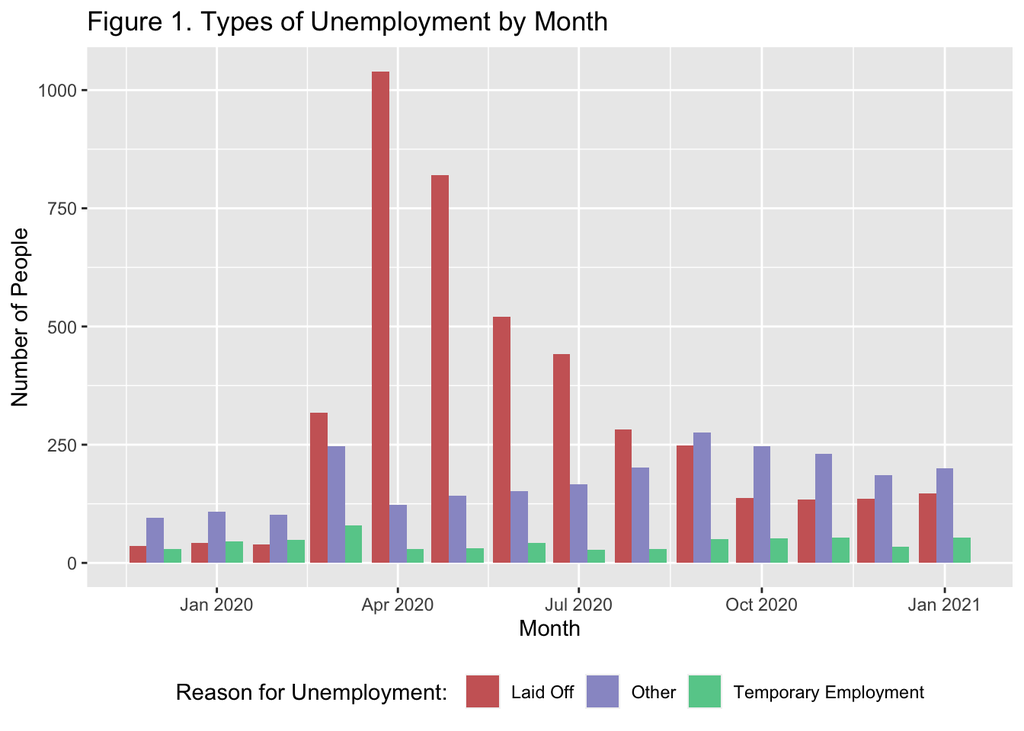

```r
sum_by_why <- t_emp %>%
  mutate(date = ymd(paste0(year, '-', month, '-01'))) %>%
  dplyr::count(date, whyunemp) %>%
  filter(date >= "2019-12-01")

plot_by_why <- sum_by_why %>%
  ggplot(aes(x = date, y = n, fill = factor(whyunemp))) +
  geom_bar(position = "dodge", stat = "identity") +
  theme(legend.position="bottom") +
  xlab("Month") +
  ylab("Number of People") +
  ggtitle('Figure 1. Types of Unemployment by Month')+
  scale_fill_manual(values=c("#CC6666", "#9999CC", "#66CC99"), name = "Reason for Unemployment: ",
                      labels=c("Laid Off", "Other", "Temporary Employment"))
plot_by_why
```

We also plotted the total number of unemployment cases reported and if the reason was COVID related. From this graph, we can see that the majority of unemployment reported in this time frame is due to COVID.

```r
sum_unemp <- t_emp %>%
  na_if(99) %>%
  mutate(date = ymd(paste0(year, '-', month, '-01'))) %>%
  dplyr::count(date, covidunaw) %>%
  filter(covidunaw %in% c(NA, 1, 2)) %>%
  filter(date >= "2019-11-01") %>%
  mutate_all(funs(ifelse(is.na(.), 0, .)))
```

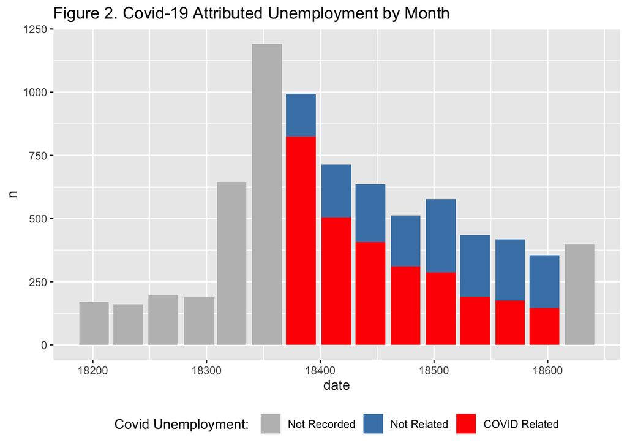

```r
plot_total <- ggplot(data = sum_unemp, aes(x = date, y = n, fill = factor(covidunaw))) +
  geom_bar(position = "stack", stat = "identity") +
  scale_fill_manual(name = "Covid Unemployment: ",
                      labels = c("Not Recorded", "Not Related", "COVID Related"),
                      values = c('gray', "steel blue", "red")) +
  theme(legend.position="bottom") +
  ggtitle('Figure 2. Covid-19 Attributed Unemployment by Month')
plot_total
```

Seeing the spike in unemployment at the beginning of 2020 in Figure 1. above and Figure 2., we established an initial hypothesis that COVID-19 measures imposed to reduce the spread of the disease were negatively impacting the retail industry’s health. Primarily, we looked at lockdown orders:

**H0** = As measured by unemployment, COVID had no impact on retail industry health. (*Key*: COVID had no impact.)

**H1** = Retail industry health was affected by COVID related measures, specifically stay at home orders. (*Key*: COVID related measures: lock downs.)

The following regression model assessed if there was a relationship between Lockdown start dates, covid related unemployment and retail layoffs. The model included a LSDV factor for states to provide a fixed effect control for collective variables such as politics, which could have influenced COVID-19 government policy implementation during that time.

```r
# Regression

# model of state lockdown order start dates, impact of covid on unemployment, state and layoffs.
m1_state_closure_layoff <- lm_robust(layoff ~ lockdown_start + covid_impact_yes + factor(state), data = exp_emp)

# Find any relationship from model 1.
export_summs(m1_state_closure_layoff, model.names = 'Covid Related Unemployment v.\nLayoffs v. Lockdown')
```

```
## 1 coefficient  not defined because the design matrix is rank deficient
```

|  | Covid Related Unemployment v. Layoffs v. Lockdown |
| --- | --- |
| (Intercept) |  |
| lockdown_start | 0.00 *** |
|  | (0.00) |
| covid_impact_yes | -0.42 *** |
|  | (0.01) |
| factor(state)Alaska | -0.03 |
|  | (0.10) |
| factor(state)Arizona | 0.09 |
|  | (0.08) |
| factor(state)California | -0.05 |
|  | (0.07) |
| factor(state)Colorado | -0.14 |
|  | (0.09) |
| factor(state)Connecticut | 0.01 |
|  | (0.10) |
| factor(state)Delaware | 0.09 |
|  | (0.08) |
| factor(state)District of Columbia | -0.20 * |
|  | (0.09) |
| factor(state)Florida | -0.11 |
|  | (0.07) |
| factor(state)Georgia | -0.30 *** |
|  | (0.08) |
| factor(state)Hawaii | 0.01 |
|  | (0.08) |
| factor(state)Idaho | -0.08 |
|  | (0.10) |
| factor(state)Illinois | -0.06 |
|  | (0.08) |
| factor(state)Indiana | -0.14 |

[output cut: 74 more lines]

In the first model, you can see that lock down orders had a significant relationship between layoffs, lockdowns and COVID related unemployment due to the states being factored. This is because some states remained open, while some didn’t which could explain why there was high rates of unemployment due to the states being closed down. To better understand what may have led to this relationship, we have decided to factor out the states. For this analysis to occur we are assuming that lock down orders did not have an effect on unemployment.

```r
# 2nd Regression.

# model of state lockdown order start dates, impact of covid on unemployment, and layoffs.
m2_state_closure_layoff <- lm_robust(layoff ~ lockdown_start + covid_impact_yes, data = exp_emp)

# Find any relationship from model 1.
export_summs(m2_state_closure_layoff, model.names = 'Covid Related Unemployment v.\nLayoffs v. Lockdown')
```

|  | Covid Related Unemployment v. Layoffs v. Lockdown |
| --- | --- |
| (Intercept) | 1.26 |
|  | (3.67) |
| lockdown_start | -0.00 |
|  | (0.00) |
| covid_impact_yes | -0.43 *** |
|  | (0.01) |
| nobs | 4440 |
| r.squared | 0.18 |
| adj.r.squared | 0.18 |
| statistic | 478.84 |
| p.value | 0.00 |
| df.residual | 4437.00 |
| nobs.1 | 4440.00 |
| se_type | HC2.00 |
| *** p < 0.001; ** p < 0.01; * p < 0.05. |  |

### Additional analysis

Next, we decided to look at the data using unemployment rates within the data as our metric (rather than number of layoffs).

```r
employment_data <- read_dta('Q1_1.dta.zip')

states <- read_csv('state_codes.csv')
```

Filter for only desired employment variables and values:

`empstat`: Values between 10 and 29 relate to people in the labor market. `ind`: Values between 4670 and 5790 indicate the retail industry

```r
t_employment <- employment_data %>%
  filter(ind>=4670 & ind<=5790) %>%
  filter(empstat < 30 & empstat >= 10) %>%
  mutate(emp_Status = empstat, industry = ind)
```

Create a binary variable to indicate employment status, 0 = unemployed, 1 = employed

```r
t_employment <- t_employment %>%
  mutate(employed = ifelse(empstat < 20, 1, 0))
```

Create a variable to indicate whether data point is from before or after COVID, 0 = pre-covid, 1 = post-covid Add a year_month variable for grouping during analysis

```r
t_employment <- t_employment %>%
  mutate(month = as.factor(month)) %>%
  mutate(year_month = ym(paste0(year, '-', month))) %>%
  mutate(post_covid = ifelse(year_month > '2020-03-01', 1, 0))
```

Select only desired variables.

```r
t_employment <- t_employment %>%
  select(year, month, employed, year_month, post_covid, statefip) %>%
  mutate(statefip = as.numeric(statefip)) %>%
  mutate(for_count = 1)
```

Replace numeric state codes with state names.

```r
t_employment <- t_employment %>%
  left_join(states, "statefip") %>%
  mutate(state = statename) %>%
  select(-statefip, -statename)
```

Group and summarise data by date only.

```r
t_employment_group <- t_employment %>%
  group_by(year_month) %>%
  summarise(num_employable = sum(for_count),
            num_employed = sum(employed==1),
            num_unemployed = num_employable - num_employed) %>%
  mutate(percent_unemployed = num_unemployed/num_employable,
         post_covid = ifelse(year_month > '2020-03-01', 1, 0))
```

Group and summarise by date and state. We want to look at data grouped by state because we suspect that a lot back-door variation will come from economic and political differences between states.

```r
t_employment_group_2 <- t_employment %>%
  group_by(state, year_month) %>%
  summarise(num_employable = sum(for_count),
            num_employed = sum(employed==1),
            num_unemployed = num_employable - num_employed) %>%
  mutate(percent_unemployed = num_unemployed/num_employable,
         post_covid = ifelse(year_month > '2020-03-01', 1, 0))
```

Before running a regression, we’ll graph unemployment trends across time, both grouped by state and not grouped by state.

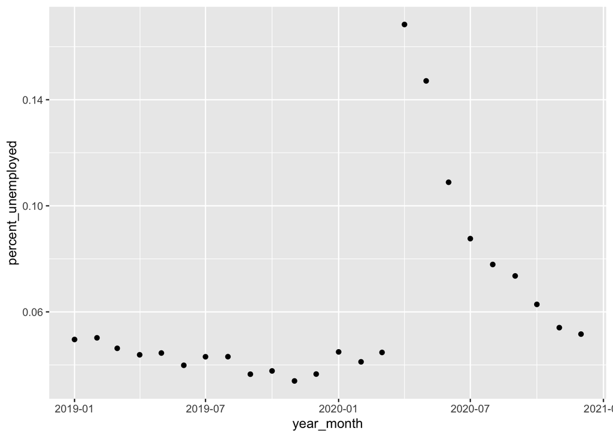

```r
t_employment_group %>%
  ggplot(aes(x=year_month, y=percent_unemployed)) +
  geom_point()
```

If we run the same graph but with data points grouped by state, we see a similar trend overall, but a significant amount of variation each month based on state. This is an indicator that we should control for state in our regression.

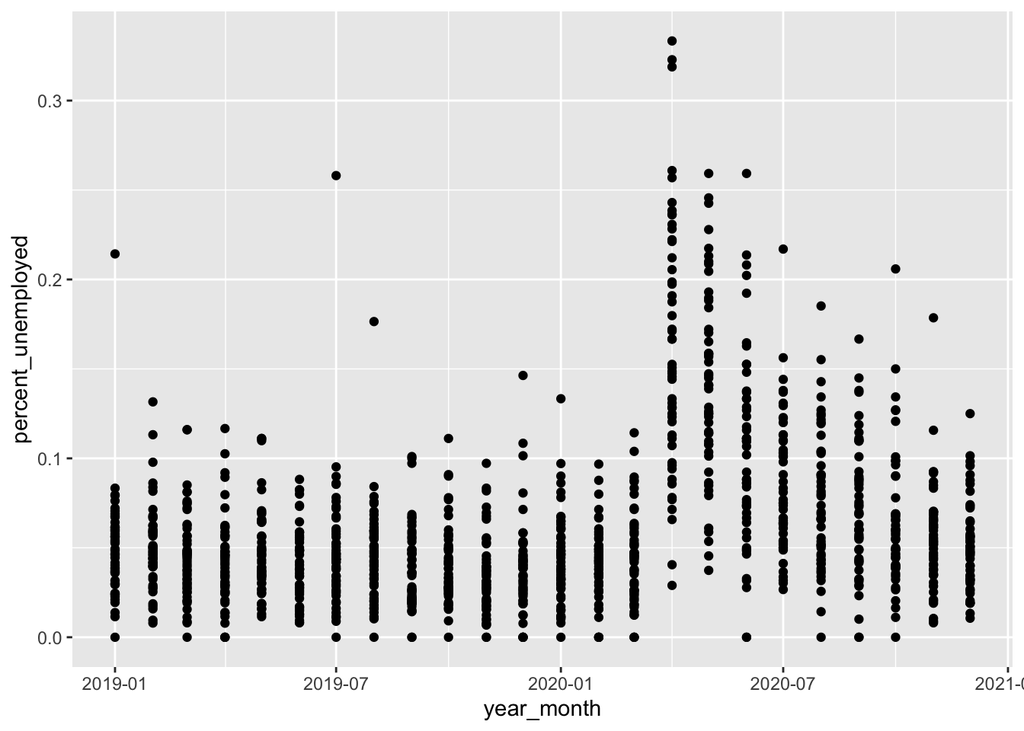

```r
t_employment_group_2 %>%
  ggplot(aes(x=year_month, y=percent_unemployed, group=state)) +
  geom_point()
```

Given that we have panel data and our graphs indicate a lot of between-state variation, we chose a fixed effects model to look at pre- and post-covid changes while controlling for state variations.

```r
m1 <- t_employment_group_2 %>%
  feols(percent_unemployed~post_covid | state)

etable(m1)
```

| m1 |
| --- |
| percent_unemployed |
| 0.0467*** (0.0036) |
| ------------------ |
| Yes |
| __________________ |
| by: state |
| 1,224 |
| 0.38618 |
| 0.27618 |

Looking at our results, we can conclude that, when controlling for state, monthly average post-covid unemployment rates are 4.67 percent higher than average monthly pre-covid unemployment rates. This is true at a .001 level of significance.

### Assumption Acknowledgement

1. Our first assumption was that we can control for many economic and political differences by controlling for state.
2. Based on the reports during this timeframe, we assume that the total COVID cases reported are accurate. While higher cases of COVID may have occurred earlier in 2020, they may have gone unreported. We are assuming that all data for COVID cases is correct.
3. We assume unemployment is the main indicator of retail industry performance. It is assumed that a healthy retail industry has a steady flow of customers contributing to steady revenue flow, enabling it to maintain uniformly sized employee pools.

### Final Results: “How Did COVID Impact the Retail Industry as Measured by Unemployment?”

Our first regression shows a statistically significant relationship between layoffs, lockdown start-dates, and COVID-related unemployment.

Our final regression shows a statistically significant increase in monthly average unemployment rates post-Covid (April 2020 - December 2020) versus pre-Covid (January 2019 - March 2020).

# Question 2 Analysis

[IPMUS employment data](https://cps.ipums.org/cps/index.shtml) was used in this analysis, with sample dates ranging from January 2019 to December of 2021. The following variables were used:

| Variable | Definition |
| --- | --- |
| `year` | survey year |
| `serial` | household serial number |
| `month` | month |
| `hwtfinal` | Household weight, Basic Monthly |
| `cpisid` | CPSID, household record |
| `asecflag` | Flag for ASEC |
| `pernum` | Person number in sample unit |
| `wtfinl` | Final Basic Weight |
| `cpsidp` | CPSID, person record |
| `empstat` | Employment status |
| `ind` | Industry Identifier |
| `indname` | Industry name |
| `industry_cat` | Whether the industry is considered to be Retail or Non-Retail |
| `date` | The date of the survey |
| `covid_active` | A binary flag indicating covid was active |

```
               0 : date < '2020-03'
               1 : date >= '2020-03'|
```

### Plotting the Datasource

The first graph is displaying the employment change percentage per month by the two industry categories, retail and non-retail

The second graph is displaying the employment change percentage per month by each industry

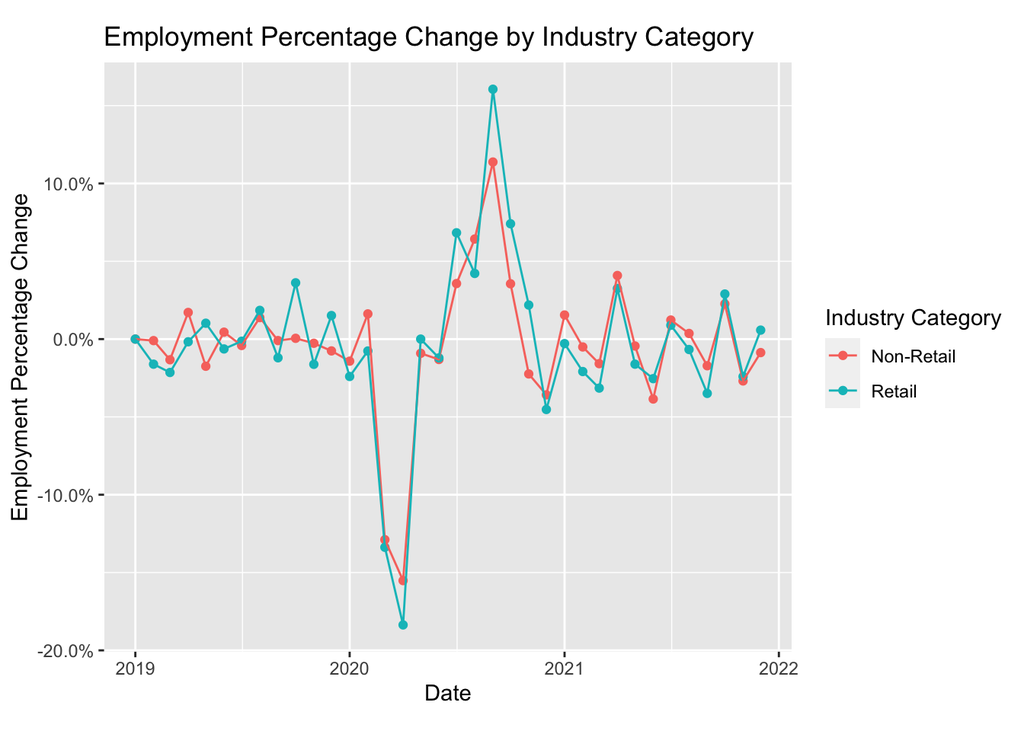

```r
industry_cat_df %>%
  ggplot(aes(x=date,y=percent_change,group=industry_cat,color=industry_cat)) +
  scale_y_continuous(labels=scales::percent_format(accuracy=.1)) +
  geom_point() + geom_line() + theme(aspect.ratio=6/7) +
  labs(x="Date",y="Employment Percentage Change",color="Industry Category",
       title= "Employment Percentage Change by Industry Category")
```

[figure not shown]

```r
industry_df %>%
  ggplot(aes(x=date,y=percent_change,group=indname,color=indname)) +
  scale_y_continuous(labels=scales::percent_format(accuracy=.1)) +
  geom_point() + geom_line() + theme(aspect.ratio=1) +
  labs(x="Date",y="Employment Percentage Change",color="Industry Name",
       title= "Employment Percentage Change by Industry")
```

The second chart will need to be zoomed in on, outside of the html file.

These graphs show two facts about the employment data: 1)There was a severe employment drop around March 2020, followed by an employment correction in late 2020 2)Retail employment change appears to be slightly more volatile than Non-Retail. This could be due to the fact that Retail is only one industry while Non-Retail is a combination of a large grouping of industries ### Summary Statistics

```r
industry_cat_df %>% filter(industry_cat == 'Retail')%>%
                    sumtable(title= 'Retail Summary Statistics')
```

Retail Summary Statistics

| Variable | N | Mean | Std. Dev. | Min | Pctl. 25 | Pctl. 75 | Max |
| --- | --- | --- | --- | --- | --- | --- | --- |
| industry_cat | 36 |  |  |  |  |  |  |
| … Retail | 36 | 100% |  |  |  |  |  |
| year | 36 | 2020 | 0.828 | 2019 | 2019 | 2021 | 2021 |
| covid_active | 36 | 0.611 | 0.494 | 0 | 0 | 1 | 1 |
| count | 36 | 5381.528 | 566.052 | 4084 | 5130 | 5835.25 | 6044 |
| percent_change | 36 | -0.003 | 0.054 | -0.184 | -0.021 | 0.016 | 0.161 |

```r
industry_cat_df %>% filter(industry_cat == 'Non-Retail')%>%
                    sumtable(title= 'Non-Retail Summary Statistics')
```

Non-Retail Summary Statistics

| Variable | N | Mean | Std. Dev. | Min | Pctl. 25 | Pctl. 75 | Max |
| --- | --- | --- | --- | --- | --- | --- | --- |
| industry_cat | 36 |  |  |  |  |  |  |
| … Non-Retail | 36 | 100% |  |  |  |  |  |
| year | 36 | 2020 | 0.828 | 2019 | 2019 | 2021 | 2021 |
| covid_active | 36 | 0.611 | 0.494 | 0 | 0 | 1 | 1 |
| count | 36 | 46193.25 | 4644.624 | 36745 | 43745.75 | 50982.75 | 51703 |
| percent_change | 36 | -0.004 | 0.044 | -0.155 | -0.015 | 0.014 | 0.114 |

### Creating a regression df for question 2

```r
q2_reg_df <- filtered_df %>%
  ungroup()%>%
  group_by(date,industry_cat)%>%
  mutate(avg_employment = mean(emp_count))%>%
  select(c('industry_cat','year','date','covid_active','avg_employment'))%>%
  distinct()%>%
  ungroup()%>%
  group_by(industry_cat)%>%
  mutate(employment_change = ((avg_employment-lag(avg_employment))))%>%
  drop_na()
```

### Regressions

#### First Regression

```r
q2_reg1 <- feols(log(emp_count)~indname,se= 'hetero',data= filtered_df)
q2_reg1.1 <- feols(log(emp_count)~indname + covid_active,se='hetero',data= filtered_df)
etable(q2_reg1,q2_reg1.1)
```

| q2_reg1 | q2_reg1.1 |
| --- | --- |
| log(emp_count) | log(emp_count) |
| 7.229*** (0.0004) | 7.325*** (0.0002) |
| 1.154*** (0.0006) | 1.148*** (0.0004) |
| 0.9940*** (0.0005) | 0.9944*** (0.0003) |
| 2.171*** (0.0004) | 2.171*** (0.0002) |
| 0.9430*** (0.0005) | 0.9441*** (0.0002) |
| -0.4518*** (0.0007) | -0.4527*** (0.0004) |
| 1.285*** (0.0005) | 1.283*** (0.0002) |
| 0.5866*** (0.0006) | 0.5843*** (0.0003) |
| 1.506*** (0.0005) | 1.507*** (0.0002) |
| 0.6870*** (0.0005) | 0.6900*** (0.0003) |
| 1.367*** (0.0005) | 1.368*** (0.0003) |
| 0.7453*** (0.0005) | 0.7467*** (0.0003) |
| -0.1750*** (0.0006) | -0.1741*** (0.0004) |
|  | -0.1683*** (9.07e-5) |
| ___________________ | ____________________ |
| Heteroskedast.-rob. | Heteroskedasti.-rob. |
| 1,856,692 | 1,856,692 |
| 0.97281 | 0.98942 |
| 0.97281 | 0.98942 |

This regression was to see how the Retail interaction coefficient on the log of employment count compared to the other industries. RetailTrade related to a 136% increase in employment count, and was statistically significant. When comparing RetailTrade to the other indnames it had on of the highest coefficient. This etable also included another regression to see if covid_active had a negative relationship to employment count, which it did at -16%.

#### Second Regression

```r
q2_reg2 <- feols(log(emp_count)~industry_cat,se='hetero',data= filtered_df)
q2_reg2.1 <- feols(log(emp_count)~industry_cat + covid_active,se='hetero',data= filtered_df)
etable(q2_reg2,q2_reg2.1)
```

| q2_reg2 | q2_reg2.1 |
| --- | --- |
| log(emp_count) | log(emp_count) |
| 8.499*** (0.0005) | 8.596*** (0.0007) |
| 0.0975*** (0.0006) | 0.0983*** (0.0006) |
|  | -0.1700*** (0.0009) |
| __________________ | ___________________ |
| Heteroskedas.-rob. | Heteroskedast.-rob. |
| 1,856,692 | 1,856,692 |
| 0.00213 | 0.01908 |
| 0.00213 | 0.01908 |

This regression is similar to the first regression except it was on the industry category field that grouped all industries into a binary variable of ‘Retail’ and ‘Non-Retail’. This once again showed that there is a positive correlation between retail employment count. We worry about this regression being misunderstood because it isn’t a regression that displays how retail fared compared to the other industries.

### Assumptions

1.Filtered out CPSID with a value of ‘0’ because they are ASEC oversample 2.Employment is a direct indicator on how well an industry is operating 3.industry_df is how we defined our industry “buckets”?

### Final Results: How has retail fared relative to other industries?

Regression q2_reg1 is going to be the best indicator with how retail fared against the other industries. Retail was in the top 3 employment industries, please review the below table to see the ratings.

| Industry | Coefficient on Employment |
| --- | --- |
| `EducationalServices,andHealthCareandSocialAssistance` | 2.171 |
| `Professional,Scientific,andManagement,andAdministrativeandWasteManagementServices` | 1.506 |
| `RetailTrade` | 1.367 |
| `Manufacturing` | 1.285 |
| `Arts,Entertainment,andRecreation,andAccommodationandFoodServices` | 1.154 |
| `Construction` | 0.9940 |
| `FinanceandInsurance,andRealEstateandRentalandLeasing` | 0.9430 |
| `TransportationandWarehousing,andUtilities` | 0.7453 |
| `PublicAdministration` | 0.6870 |
| `OtherServices,ExceptPublicAdministration` | 0.5866 |
| `Information` | -0.4518 |

# Question 3 Analysis

The below table summarizes our regression of type of industry respondent claimed to work and time period on reported employment.

| Industry | % Change |
| --- | --- |
| `Arts,Entertainment,andRecreation,andAccommodationandFoodServices` | -%05.22 |
| `Construction` | -%00.95 |
| `EducationalServices,andHealthCareandSocialAssistance` | %01.59 |
| `FinanceandInsurance,andRealEstateandRentalandLeasing` | %02.37 |
| `Information` | %00.02 |
| `Manufacturing` | %00.81 |
| `OtherServices,ExceptPublicAdministration` | -%00.10 |
| `Professional,Scientific,andManagement,andAdministrativeandWasteManagementServices` | %00.32 |
| `PublicAdministration` | %03.07 |
| `RetailTrade` | -%00.66 |
| `TransportationandWarehousing,andUtilities` | -%00.13 |
| `WholesaleTrade` | %01.36 |
| `period_typeCovid` | -%00.81 |
| `period_typePost_Covid` | -%2.92 |

### EDA

```r
# distinct people in survey = 500,130
summary(demo_data)
```

```
##      date_                 YEAR          MONTH            HHID
##  Min.   :2019-01-01   Min.   :2019   Min.   : 1.000   Length:1951872
##  1st Qu.:2019-09-01   1st Qu.:2019   1st Qu.: 3.000   Class :character
##  Median :2020-06-01   Median :2020   Median : 6.000   Mode  :character
##  Mean   :2020-05-29   Mean   :2020   Mean   : 6.464
##  3rd Qu.:2021-03-01   3rd Qu.:2021   3rd Qu.:10.000
##  Max.   :2021-12-01   Max.   :2021   Max.   :12.000
##
##      PERNUM          EMPSTAT      is_employed        employed
##  Min.   : 1.000   Min.   :10.00   Mode :logical   Min.   :0.0000
##  1st Qu.: 1.000   1st Qu.:10.00   FALSE:95180     1st Qu.:1.0000
##  Median : 1.000   Median :10.00   TRUE :1856692   Median :1.0000
##  Mean   : 1.736   Mean   :10.61                   Mean   :0.9512
##  3rd Qu.: 2.000   3rd Qu.:10.00                   3rd Qu.:1.0000
##  Max.   :16.000   Max.   :21.00                   Max.   :1.0000
##
##    unemployed          CPSID               CPSIDP             HWTFINL
##  Min.   :0.00000   Min.   :2.017e+13   Min.   :2.017e+13   Min.   :  150.7
##  1st Qu.:0.00000   1st Qu.:2.019e+13   1st Qu.:2.019e+13   1st Qu.: 1457.1
##  Median :0.00000   Median :2.019e+13   Median :2.019e+13   Median : 3196.5
##  Mean   :0.04876   Mean   :2.019e+13   Mean   :2.019e+13   Mean   : 2916.3
##  3rd Qu.:0.00000   3rd Qu.:2.020e+13   3rd Qu.:2.020e+13   3rd Qu.: 4023.9
##  Max.   :1.00000   Max.   :2.021e+13   Max.   :2.021e+13   Max.   :26194.1
##
##      WTFINL            FAMINC          REGION              METRO
##  Min.   :  135.8   Min.   :100   Midwest  :404365   CityCenter:495613
##  1st Qu.: 1489.6   1st Qu.:740   Northeast:321633   Other     :332859
##  Median : 3240.9   Median :841   South    :689489   Rural     :344367
##  Mean   : 2990.1   Mean   :781   West     :536385   Suburb    :779033
##  3rd Qu.: 4118.5   3rd Qu.:842
##  Max.   :26194.1   Max.   :843
##
##       AGE                 AgeGroup           SEX            sex
##  Min.   :15.00   20to29       :345377   Min.   :1.000   female: 931360
##  1st Qu.:31.00   30to39       :424379   1st Qu.:1.000   male  :1020512
##  Median :43.00   40to49       :398013   Median :1.000
##  Mean   :43.35   50to59       :396584   Mean   :1.477
##  3rd Qu.:55.00   60to65       :183335   3rd Qu.:2.000
##  Max.   :85.00   RetirementAge:132366   Max.   :2.000
##                  under20      : 71818
```

[output cut: 25 more lines]

```
##  Educational Services, and Health Care and Social Assistance                               :448593
##  Professional, Scientific, and Management, and Administrative and Waste Management Services:234286
##  Retail Trade                                                                              :205579
##  Manufacturing                                                                             :186276
##  Arts, Entertainment, and Recreation, and Accommodation and Food Services                  :172133
##  Construction                                                                              :142071
##  (Other)                                                                                   :562934
##  retail_v_other            State             period_type
##  Other :1746293   California  : 165973   Pre_Covid : 825858
##  Retail: 205579   Texas       : 108933   Covid     :  51630
##                   Florida     :  83491   Post_Covid:1074384
##                   New York    :  73964
##                   Illinois    :  53925
##                   Pennsylvania:  52650
##                   (Other)     :1412936
```

```r
vtable(demo_data, lush = TRUE)
```

demo_data

| Name | Class | Label | Values | Missing | Summary |
| --- | --- | --- | --- | --- | --- |
| date_ | Date | NULL | Time: 2019-01-01 to 2021-12-01 | 0 | mean: 18411.8421587071, sd: 318.778, nuniq: 36 |
| YEAR | numeric | Survey year | Num: 2019 to 2021 | 0 | mean: 2019.956, sd: 0.825, nuniq: 3 |
| MONTH | integer | Month | Num: 1 to 12 | 0 | mean: 6.464, sd: 3.484, nuniq: 12 |
| HHID | character | NULL | ‘100001282510304_8111’ ‘100001284910704_11011’ ‘100001708810114_13011’ ‘10000190126366_11011’ ‘10000190126366_8011’ and more | 0 | nuniq: 282850 |
| PERNUM | numeric | Person number in sample unit | Num: 1 to 16 | 0 | mean: 1.736, sd: 1.068, nuniq: 16 |
| EMPSTAT | integer | Employment status | Num: 10 to 21 | 0 | mean: 10.611, sd: 2.383, nuniq: 3 |
| is_employed | logical | NULL | TRUE FALSE | 0 | mean: 0.951, sd: 0.215, nuniq: 2 |
| employed | numeric | NULL | Num: 0 to 1 | 0 | mean: 0.951, sd: 0.215, nuniq: 2 |
| unemployed | numeric | NULL | Num: 0 to 1 | 0 | mean: 0.049, sd: 0.215, nuniq: 2 |
| CPSID | numeric | CPSID, household record | Num: 20171000000400 to 20211206841100 | 0 | mean: 20194230955716.8, sd: 10103760006.248, nuniq: 282850 |
| CPSIDP | numeric | CPSID, person record | Num: 20171000000401 to 20211206841101 | 0 | mean: 20194230955718.5, sd: 10103760006.223, nuniq: 492303 |
| HWTFINL | numeric | Household weight, Basic Monthly | Num: 150.748 to 26194.133 | 0 | mean: 2916.28, sd: 1627.751, nuniq: 847057 |
| WTFINL | numeric | Final Basic Weight | Num: 135.759 to 26194.133 | 0 | mean: 2990.088, sd: 1687.776, nuniq: 1285703 |
| FAMINC | integer | Family income of householder | Num: 100 to 843 | 0 | mean: 780.969, sd: 125.675, nuniq: 16 |
| REGION | factor | NULL | ‘Midwest’ ‘Northeast’ ‘South’ ‘West’ | 0 | nuniq: 4 |
| METRO | factor | NULL | ‘CityCenter’ ‘Other’ ‘Rural’ ‘Suburb’ | 0 | nuniq: 4 |
| AGE | integer | Age | Num: 15 to 85 | 0 | mean: 43.352, sd: 14.868, nuniq: 67 |
| AgeGroup | factor | NULL | ‘20to29’ ‘30to39’ ‘40to49’ ‘50to59’ ‘60to65’ and more | 0 | nuniq: 7 |
| SEX | integer | Sex | Num: 1 to 2 | 0 | mean: 1.477, sd: 0.499, nuniq: 2 |
| sex | factor | NULL | ‘female’ ‘male’ | 0 | nuniq: 2 |
| RACE | factor | NULL | ‘AmericanIndian’ ‘Asian’ ‘Black’ ‘Latino’ ‘MixedRace’ and more | 0 | nuniq: 6 |
| MARST | factor | NULL | ‘Married’ ‘Single’ | 0 | nuniq: 2 |
| IND | numeric | Industry | Num: 170 to 9890 | 0 | mean: 6279.131, sd: 2698.816, nuniq: 279 |
| WHYUNEMP | factor | NULL | ‘FirstJob’ ‘LostJob’ ‘Quit’ ‘ReEnterLaborForce’ | 0 | nuniq: 3 |
| Education | factor | NULL | ‘AssociateDegree’ ‘Bachelors’ ‘HighSchoolDiploma’ ‘Masters’ ‘NoDiploma’ and more | 0 | nuniq: 7 |
| LaborForce | factor | NULL | ‘1’ | 0 | nuniq: 1 |
| EmploymentStatus | factor | NULL | ‘0’ ‘1’ | 0 | nuniq: 2 |
| WorkStatus | factor | NULL | ‘FullTime’ ‘FullTimeNoWork’ ‘NoWorkSeekingFullTime’ ‘NoWorkSeekingPartTime’ ‘PartTime’ and more | 0 | nuniq: 6 |
| FamilyIncome | factor | NULL | ‘<$25k_FPL_Familyof4’ ‘100k - 150k’ ‘150k+’ ‘25k-50K’ ‘50k-75k’ and more | 0 | nuniq: 6 |
| indname | factor | NULL | ‘Agriculture, Forestry, Fishing, and Hunting, and Mining’ ‘Arts, Entertainment, and Recreation, and Accommodation and Food Services’ ‘Construction’ ‘Educational Services, and Health Care and Social As… | 0 | nuniq: 14 |
| retail_v_other | factor | NULL | ‘Other’ ‘Retail’ | 0 | nuniq: 2 |
| State | factor | NULL | ‘Alabama’ ‘Alaska’ ‘Arizona’ ‘Arkansas’ ‘California’ and more | 0 | nuniq: 51 |
| period_type | factor | NULL | ‘Pre_Covid’ ‘Covid’ ‘Post_Covid’ | 0 | nuniq: 3 |

```r
reg_df_vis<- demo_data %>%
  select(period_type
         , date_
         ## Measure
         , is_employed
         , WTFINL
         ## Variables
         , IND, indname, REGION
         ## Fixed
         , AGE, sex, RACE
  )
```

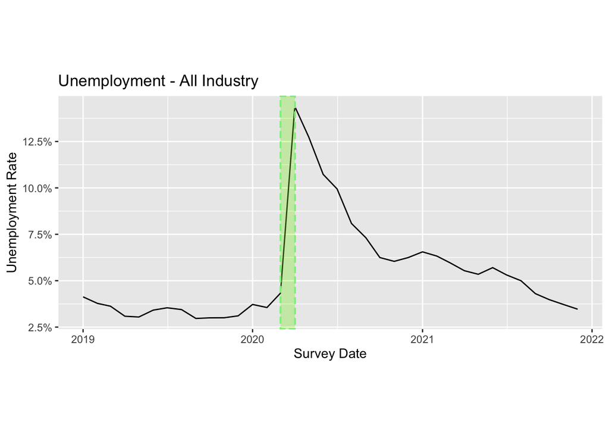

```r
## All industries unemployment rate over time
unemp_time <- demo_data %>%
  filter(indname != 'Military', indname != 'Other') %>%
  group_by(date_) %>%
  summarize(UnemploymentRate = 1- (weighted.mean(is_employed == TRUE, w = WTFINL))) %>%
  ggplot(aes(x = date_, y = UnemploymentRate)) + geom_line()+
  geom_rect(aes(xmin=as_date('2020-03-01'), xmax=as_date('2020-04-01'), ymin=-Inf, ymax=Inf),  linetype = 'dashed',color="light green", fill = 'light green' ,alpha=.01)+
  scale_y_continuous(labels = scales::percent_format(accuracy = .1))+
  labs(x = "Survey Date", y = "Unemployment Rate",
    title ="Unemployment - All Industry")+
  theme(aspect.ratio=3/7)
unemp_time
```

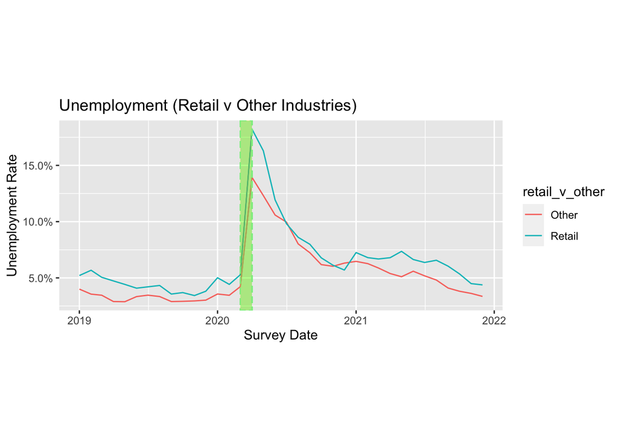

```r
## All industries v retail unemployment rate over time
unemp_retail_time <- demo_data %>%
  filter(indname != 'Military', indname != 'Other') %>%
  group_by(date_, retail_v_other) %>%
  summarize(UnemploymentRate = 1- (weighted.mean(is_employed == TRUE, w = WTFINL))) %>%
  ggplot(aes(x = date_, y = UnemploymentRate, color = retail_v_other)) + geom_line()+
  geom_rect(aes(xmin=as_date('2020-03-01'), xmax=as_date('2020-04-01'), ymin=-Inf, ymax=Inf),  linetype = 'dashed',color="light green", fill = 'light green' ,alpha=.01)+
  labs(x = "Survey Date", y = "Unemployment Rate",
    title ="Unemployment (Retail v Other Industries)")+
  scale_y_continuous(labels = scales::percent_format(accuracy = .1))+
  theme(aspect.ratio=3/7)
unemp_retail_time
```

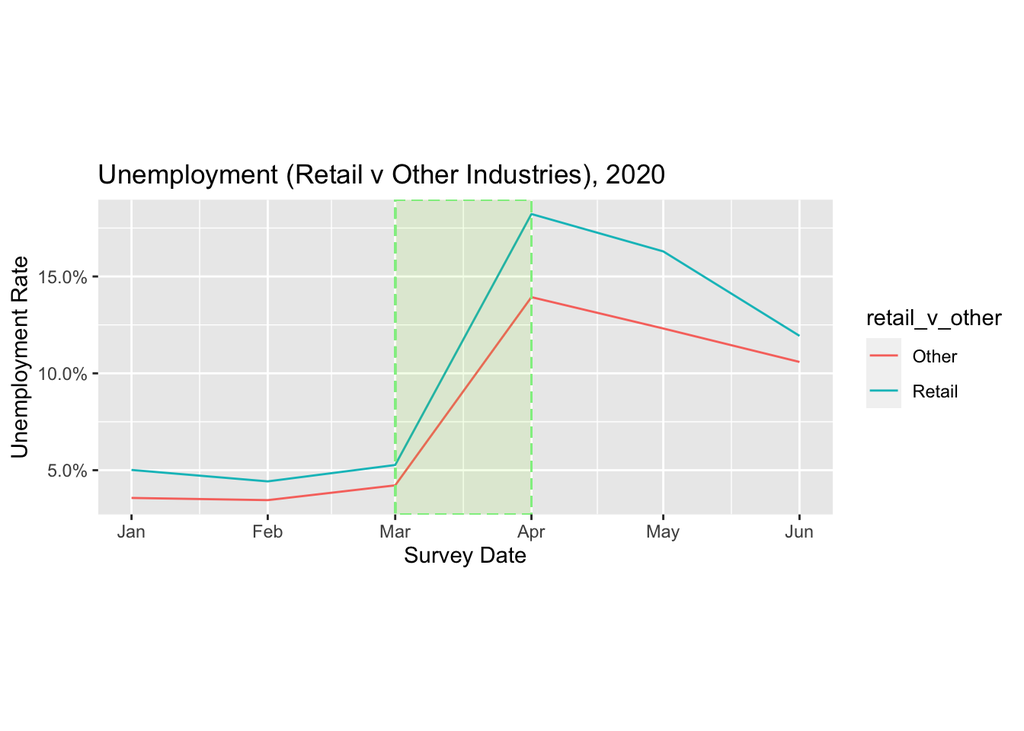

```r
## limit x window for clarity
unemp_time_skinny <- demo_data %>%
  filter(date_>=as_date('2020-01-01'),
         date_<= as_date('2020-06-01')) %>%
  filter(indname != 'Military', indname != 'Other') %>%
  group_by(date_, retail_v_other) %>%
  summarize(UnemploymentRate = 1- (weighted.mean(is_employed == TRUE, w = WTFINL))) %>%
  ggplot(aes(x = date_, y = UnemploymentRate, color = retail_v_other)) + geom_line()+
  geom_rect(aes(xmin=as_date('2020-03-01'), xmax=as_date('2020-04-01'), ymin=-Inf, ymax=Inf),  linetype = 'dashed',color="light green", fill = 'light green' ,alpha=.01)+
  labs(x = "Survey Date", y = "Unemployment Rate",
    title ="Unemployment (Retail v Other Industries), 2020")+
  scale_y_continuous(labels = scales::percent_format(accuracy = .1))+
  theme(aspect.ratio=3/7)
unemp_time_skinny
```

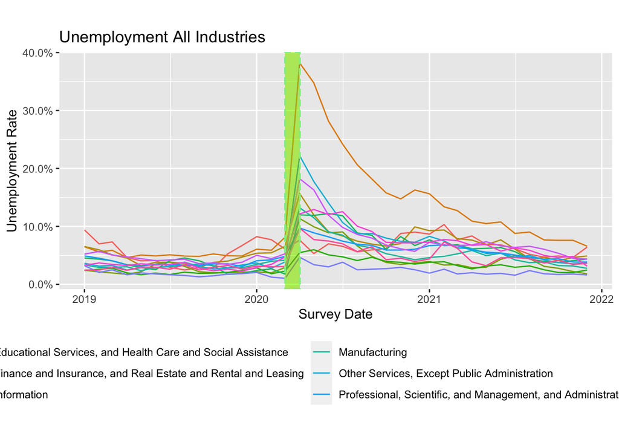

```r
unemp_industries <- demo_data %>%
  filter(indname != 'Military', indname != 'Other') %>%
  group_by(date_, indname) %>%
  summarize(UnemploymentRate = 1- (weighted.mean(is_employed == TRUE, w = WTFINL))) %>%
  ggplot(aes(x = date_, y = UnemploymentRate, color = indname)) + geom_line()+
  geom_rect(aes(xmin=as_date('2020-03-01'), xmax=as_date('2020-04-01'), ymin=-Inf, ymax=Inf),  linetype = 'dashed',color="light green", fill = 'light green' ,alpha=.01)+ labs(x = "Survey Date", y = "Unemployment Rate",
    title ="Unemployment All Industries")+
  scale_y_continuous(labels = scales::percent_format(accuracy = .1))+
  theme(aspect.ratio=3/7, legend.position = 'bottom')
unemp_industries
```

### Geographical

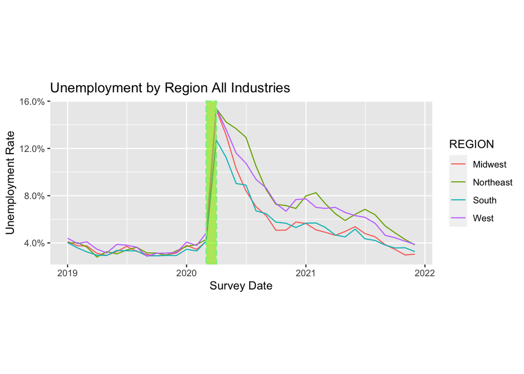

```r
unemp_by_region <- demo_data %>%
  filter(indname != 'Military', indname != 'Other') %>%
  group_by(date_, REGION) %>%
  summarize(UnemploymentRate = 1- (weighted.mean(is_employed == TRUE, w = WTFINL))) %>%
  ggplot(aes(x = date_, y = UnemploymentRate, color = REGION)) + geom_line()+
  geom_rect(aes(xmin=as_date('2020-03-01'), xmax=as_date('2020-04-01'), ymin=-Inf, ymax=Inf),  linetype = 'dashed',color="light green", fill = 'light green' ,alpha=.01)+
  labs(x = "Survey Date", y = "Unemployment Rate",
    title ="Unemployment by Region All Industries")+
  scale_y_continuous(labels = scales::percent_format(accuracy = .1))+
  theme(aspect.ratio=3/7)
unemp_by_region
```

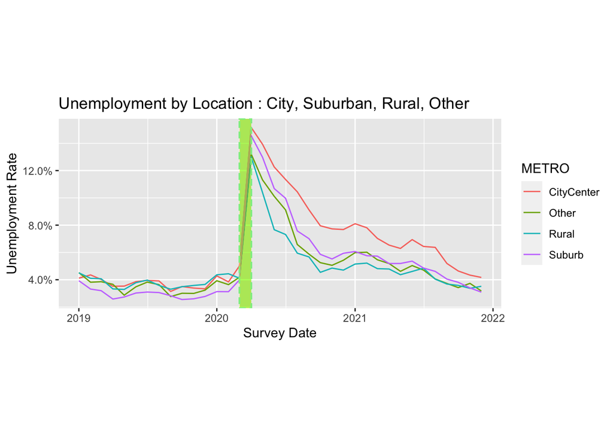

```r
unemp_by_metro <- demo_data %>%
  filter(indname != 'Military', indname != 'Other') %>%
  group_by(date_, METRO) %>%
  summarize(UnemploymentRate = 1- (weighted.mean(is_employed == TRUE, w = WTFINL))) %>%
  ggplot(aes(x = date_, y = UnemploymentRate, color = METRO)) + geom_line()+
  theme(aspect.ratio=3/7)+
  geom_rect(aes(xmin=as_date('2020-03-01'), xmax=as_date('2020-04-01'), ymin=-Inf, ymax=Inf),  linetype = 'dashed',color="light green", fill = 'light green' ,alpha=.01)+
  labs(x = "Survey Date", y = "Unemployment Rate",
    title ="Unemployment by Location : City, Suburban, Rural, Other")+
  scale_y_continuous(labels = scales::percent_format(accuracy = .1))+
  theme(aspect.ratio=3/7)
unemp_by_metro
```

During March 2020, all regions experienced sudden and parallel changes in unemployment rates and those rates, regardless if living in the city, suburbs or rural country side experienced similar unemployment rate changes. Differences in the decline of unemployment rates from April 2020 through early 2021 are remarkable for higher rates of unemployment in the Northeast and Western United States. These regions are populated with larger cities, thus it is not surprising to that unemployment in the cities was highest during this period.

### Race

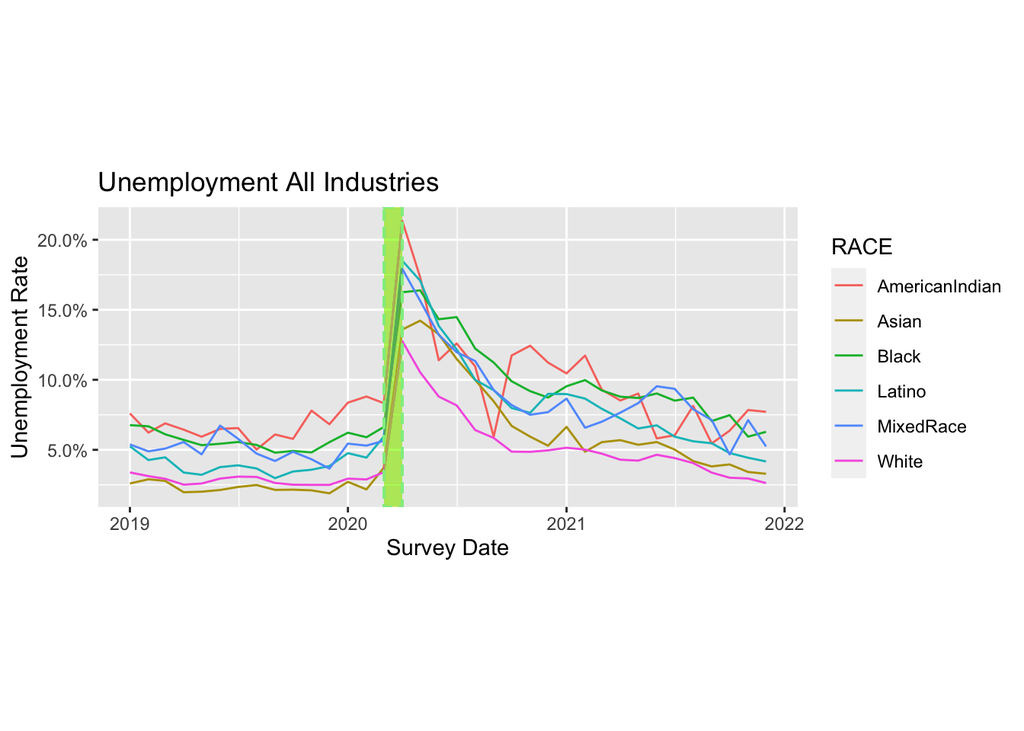

```r
#### RACE PRE-COVID EMPLOYMENT ####
unemp_by_race <- demo_data %>%
  filter(indname != 'Military', indname != 'Other') %>%
  group_by(date_, RACE) %>%
  summarize(UnemploymentRate = 1- (weighted.mean(is_employed == TRUE, w = WTFINL))) %>%
  ggplot(aes(x = date_, y = UnemploymentRate, color = RACE)) + geom_line()+
  theme(aspect.ratio=3/7)+
  geom_rect(aes(xmin=as_date('2020-03-01'), xmax=as_date('2020-04-01'), ymin=-Inf, ymax=Inf),  linetype = 'dashed',color="light green", fill = 'light green' ,alpha=.01)+
  labs(x = "Survey Date", y = "Unemployment Rate",
    title ="Unemployment All Industries")+
  scale_y_continuous(labels = scales::percent_format(accuracy = .1))+
  theme(aspect.ratio=3/7)
unemp_by_race
```

Evaluating all industry types, American Indians, African-Americans and Latino’s experienced higher unemployment rates vs Caucasians and people of Asian descent

### Age

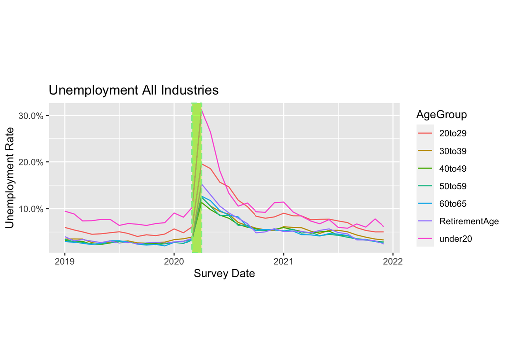

```r
unemp_by_age_group <- demo_data %>%
  filter(indname != 'Military', indname != 'Other') %>%
  group_by(date_, AgeGroup) %>%
  summarize(UnemploymentRate = 1- (weighted.mean(is_employed == TRUE, w = WTFINL))) %>%
  ggplot(aes(x = date_, y = UnemploymentRate, color = AgeGroup)) + geom_line()+
  theme(aspect.ratio=3/7)+
  geom_rect(aes(xmin=as_date('2020-03-01'), xmax=as_date('2020-04-01'), ymin=-Inf, ymax=Inf),  linetype = 'dashed',color="light green", fill = 'light green' ,alpha=.01)+
  labs(x = "Survey Date", y = "Unemployment Rate",
    title ="Unemployment All Industries")+
  scale_y_continuous(labels = scales::percent_format(accuracy = .1))+
  theme(aspect.ratio=3/7)
unemp_by_age_group
```

People less than 30 years old experienced higher rates of unemployment vs. other age categories. The 30-39, 40-49, and 50-59 age groups experienced the lowest rates of unemployment in all industries

### Regressions

```r
reg_df <- demo_data %>%
  select(period_type
         , date_
         ## Measure
         , is_employed
         , WTFINL
         ## Variables
         , IND, indname, REGION
         ## Fixed
         , AGE, sex, RACE, AgeGroup, MARST
  )

q3_reg1 <- feols(is_employed~period_type + indname, se = 'hetero', data = reg_df)
etable(q3_reg1)
```

| q3_reg1 |
| --- |
| is_employed |
| 0.9655*** (0.0010) |
| -0.0081*** (0.0009) |
| -0.0292*** (0.0003) |
| -0.0522*** (0.0012) |
| -0.0095*** (0.0012) |
| 0.0159*** (0.0010) |
| 0.0237*** (0.0011) |
| 0.0002 (0.0015) |
| 0.0081*** (0.0011) |
| -0.9502*** (0.0014) |
| -0.0010 (0.0012) |
| 0.0032** (0.0011) |
| 0.0307*** (0.0011) |
| -0.0066*** (0.0011) |
| -0.0013 (0.0012) |
| 0.0136*** (0.0013) |
| ___________________ |
| Heteroskedast.-rob. |
| 1,951,872 |
| 0.01523 |
| 0.01522 |

We ran regression 1 (reg1) to evaluate while holding industry type constant, the effect of time (pre-covid, covid, and post-covid) on whether or not respondents were employed. Our assumptions were if one had a job, there a likelihood they would have money to spend, all jobs are created equal irrespective of industry, and even though some industries had workers that changed the location of where they produced, controlling for industry was sufficient to look at simply who had jobs. The intent was to identify number of jobs in respect to three different time periods and control for industry with the assumption that even though some industries had changes as to where workers completed work. Jobs within Public Administration and Finance have done well and marketing goods and services to that strata would be pragmatic as they have a job and can spend money. The military industry should be ignored and is likely an error in data wrangling as the coefficient does not make logical sense.

-Interpretation reg1 =

-controlling for industry and relative to agricultural industry, a one-unit change in pre-covid employment is associated with a -5.22% decrease in within the Entertainment and Recreation industry.

-controlling for industry and relative to agricultural industry, a one-unit change in pre-covid employment is associated with a 2.37% increase within the Financial & Insurance services industry.

-controlling for industry and relative to agricultural industry, a one-unit change in pre-covid employment is associated with a .02% increase within the Information services industry.

-controlling for industry and relative to agricultural industry, a one-unit change in pre-covid employment is associated with a .81% increase within the Manufacturing industry.

-controlling for industry and relative to agricultural industry, a one-unit change in pre-covid employment is associated with a -.1% decrease within Other Services Industry.

-controlling for industry and relative to agricultural industry, a one-unit change in pre-covid employment is associated with a .32% increase within Professional, Scientific and Management Industry.

-controlling for industry and relative to agricultural industry, a one-unit change in pre-covid employment is associated with a -.66% decrease within Retail Trade Industry.

-controlling for industry and relative to agricultural industry, a one-unit change in pre-covid employment is associated with a -.13% decrease within Transportation & warehousing Industry.

-controlling for industry and relative to agricultural industry, a one-unit change in pre-covid employment is associated with a 1.36% increase within Wholesale Trade Industry.

```r
q3_reg2 <- feols(is_employed~indname + period_type, se = 'hetero', data = reg_df)
etable(q3_reg2)
```

| q3_reg2 |
| --- |
| is_employed |
| 0.9655*** (0.0010) |
| -0.0522*** (0.0012) |
| -0.0095*** (0.0012) |
| 0.0159*** (0.0010) |
| 0.0237*** (0.0011) |
| 0.0002 (0.0015) |
| 0.0081*** (0.0011) |
| -0.9502*** (0.0014) |
| -0.0010 (0.0012) |
| 0.0032** (0.0011) |
| 0.0307*** (0.0011) |
| -0.0066*** (0.0011) |
| -0.0013 (0.0012) |
| 0.0136*** (0.0013) |
| -0.0081*** (0.0009) |
| -0.0292*** (0.0003) |
| ___________________ |
| Heteroskedast.-rob. |
| 1,951,872 |
| 0.01523 |
| 0.01522 |

We have assumed that jobs equal money to solicit good and services to customers and that all jobs, regardless of industry are the same. Interpretations for some industries of interest in reg2 (please note:summary table above in findings). Note that values are relative to agriculture and period_type is relative to pre-covid.

-controlling for period_type and relative to agricultural industry, a one-unit change in industry employment is associated with a -5.22% decrease within the Art, Entertainment and Recreation industry.

-controlling for period_type and relative to agricultural industry, a one-unit change in industry employment is associated with a -.66% decrease within the Retail Trade industry.

-controlling for period_type and relative to agricultural industry, a one-unit change in industry employment is associated with a -.13% decrease within the Transportation & warehousing industry.

It is a bit presumptuous that a percentage increase or decrease in one industry where workers report being employed in a traditionally highly paid industry is weighted similarly to a low-skilled job paying minimum wage. The model could be improved by evaluating occupational code names from Census Bureau, evaluating median FAMINC at the annual-level of respondents that worked certain occupations, and then assigning weights to the jobs unemployment figures. Cross-referencing industry by geography could aid in determining where high-paying industries are clustered, and assuming those people working within those industries have money to spend, it would be prudent to market goods and services to that target market.

### Renaming column name in the data frames

```r
colnames(dem_data) <- c('year','household_serial','month','household_weight','cpsid','ASEC_flag',
                        'region','state_fip','metro','state_census','family_income','household_id_1',
                        'household_id_2','person_number','basic_weight','cpsid_person','age','sex','race',
                        'marital_status','hispanic','employment_status','labor_force_status','occupation',
                        'industry','hours_worked_per_week','hours_worked_last_week','how_long_unemployed',
                        'continous_unemploy',
                        'reason_unemployed','reason_absence','full_part_time_status','multiple_jobs',
                        'number_of_jobs','education','weight_earnings','hourly_wage','paid_by_hour',
                        'union','weekly_earnings','overtime_pay','month_digit','date','period_type')

colnames(Q3_DF) <- c('year','household_serial','month','household_weight','cpsid','ASEC_flag',
                        'region','state_fip','metro','state_census','family_income','household_id_1',
                        'household_id_2','person_number','basic_weight','cpsid_person','age','sex','race',
                        'marital_status','hispanic','employment_status','labor_force_status','occupation',
                        'industry','hours_worked_per_week','hours_worked_last_week','how_long_unemployed',
                        'continous_unemploy',
                        'reason_unemployed','reason_absence','full_part_time_status','multiple_jobs',
                        'number_of_jobs','education','weight_earnings','hourly_wage','paid_by_hour',
                        'union','weekly_earnings','overtime_pay','month_digit','date','period_type',
                        'region','division','state','industry_name','industry_category')


colnames(demo_data) <- c('date','year','month','household_id','person_number','employment_status',
                         'is_employed','employed','unemployed','cpsid','cpsid_person','household_weight',
                         'basic_weight','family_income','region','metro','age','age_group','sex_id','sex',
                         'race','maritial_status','industry','unemployment_reason','education',
                         'in_labor_force','employment_status','work_status','family_income','industry_name',
                         'retail_v_other','state','period_type')

colnames(employment_data) <- c('year','household_serial','month','household_weight','cpsid','ASEC_flag',
                               'state_fip','person_number','basic_weight','cpsid_person','employment_status',
                               'occupation','industry','work_status','covid_remote_work',
                               'covid_unable_to_work')

colnames(exp_emp) <- c('year','month','state_fip','employment_status','occupation_2010',
                       'duration_employment','why_unemployed','covid_unable_to_work','survey_dates',
                       'layoff','other_type_loss','temp_employee','covid_impact_no','covid_impact_yes',
                       'state','lockdown_start')

colnames(filtered_df) <- c('year','household_serial','month','household_weight','cpsid','employment_status',
                           'industry','industry_name','industry_category','date','covid_active',
                           'employment_count')

colnames(industry_cat_df) <- c('industry_category','year','date','covid_active','count','percent_change')

colnames(industry_df) <- c('industry_name','year','date','covid_active','count','percent_change')

colnames(industry_names) <- c('industry_name','industry','industry_category')

colnames(q1_employment) <- c('year','household_serial','month','state_fip','employment_status',
                             'occupation_2010','employment_duration','unemployment_reason',
                             'covid_unable_to_work')

colnames(q2_data) <- c('year','household_serial','month','household_weight','cpsid','ASEC_flag',
                       'person_number','weight_final','cpsid_person','employment_status','industry')

colnames(q2_df) <- c('year','household_serial','month','household_weight','cpsid','ASEC_flag',
                       'person_number','weight_final','cpsid_person','employment_status','industry',
                     'industry_name','industry_category','date','covid_active')

colnames(q2_reg_df) <-c('industry_category','year','date','covid_active','avg_employment',
                        'employment_changes')

colnames(sum_by_why) <- c('date','why_unemployed','count')

colnames(t_emp) <- c('year','month','state_fip','employment_status','occupation_2010',
                     'duration_unemployed','why_unemployed','covid_unable_to_work')
```